# Campaign Contributions and Bureaucratic Oversight

## Pro-Business Letters per cycle ~ Energy Sector PAC contributions per cycle 1998-2018

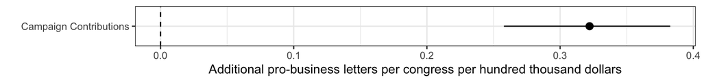

```r
mPro <- glm(ProBusiness_Letters ~ PAC_100k,
            data = letters_money %>%
              filter(industry == "energy") %>%
              select(icpsr, congress, party_name,PAC_100k, chamber,ProBusiness_Letters) %>%
              distinct(),
            family = poisson)

mPro %>% mplot()+
  labs(x="", y="Additional pro-business letters per congress per hundred thousand dollars")
```

```r
mPro %>% ratio()
```

| party_name | PAC_100k | .fitted | ratio |
| --- | --- | --- | --- |
| Democratic Party | 0 | 0.2250146 | 1.000000 |
| Democratic Party | 1 | 0.3105348 | 1.380065 |
| Democratic Party | 2 | 0.4285582 | 1.904580 |
| Democratic Party | 3 | 0.5914383 | 2.628444 |
| Democratic Party | 4 | 0.8162233 | 3.627424 |
| Democratic Party | 5 | 1.1264413 | 5.006081 |
| Republican Party | 0 | 0.2250146 | 1.000000 |
| Republican Party | 1 | 0.3105348 | 1.380065 |
| Republican Party | 2 | 0.4285582 | 1.904580 |
| Republican Party | 3 | 0.5914383 | 2.628444 |
| Republican Party | 4 | 0.8162233 | 3.627424 |
| Republican Party | 5 | 1.1264413 | 5.006081 |

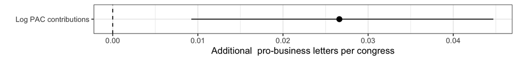

```r
mProLog <- glm(ProBusiness_Letters ~ Log_PAC_contributions,
              data = letters_money %>%
              filter(industry == "energy") %>%
              select(icpsr, congress,party_name, chamber,Log_PAC_contributions, ProBusiness_Letters) %>%
              distinct(),
            family = poisson)

mProLog %>% mplot()+
  labs(x="", y="Additional  pro-business letters per congress")
```

### Pro-business letters by party

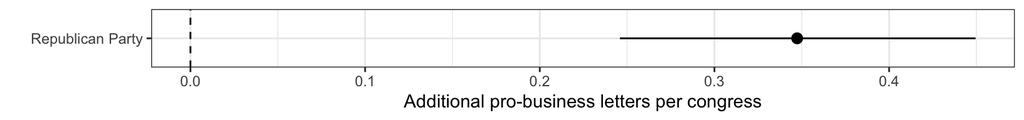

```r
mProParty <- glm(ProBusiness_Letters ~ party_name,
                 data = letters_money %>%
                   filter(industry == "energy") %>%
                   filter(party_name != "Independent") %>%
                   select(icpsr, congress, party_name, chamber,ProBusiness_Letters, PAC_100k) %>%
              distinct(),
            family = poisson)

# tidy(mProParty)
mplot(mProParty) +
  labs(x="", y="Additional pro-business letters per congress")
```

```r
ratio(mProParty)
```

| party_name | PAC_100k | .fitted | ratio |
| --- | --- | --- | --- |
| Democratic Party | 0 | 0.2119454 | 1 |
| Democratic Party | 1 | 0.2119454 | 1 |
| Democratic Party | 2 | 0.2119454 | 1 |
| Democratic Party | 3 | 0.2119454 | 1 |
| Democratic Party | 4 | 0.2119454 | 1 |
| Democratic Party | 5 | 0.2119454 | 1 |
| Republican Party | 0 | 0.2999674 | 1 |
| Republican Party | 1 | 0.2999674 | 1 |
| Republican Party | 2 | 0.2999674 | 1 |
| Republican Party | 3 | 0.2999674 | 1 |
| Republican Party | 4 | 0.2999674 | 1 |
| Republican Party | 5 | 0.2999674 | 1 |

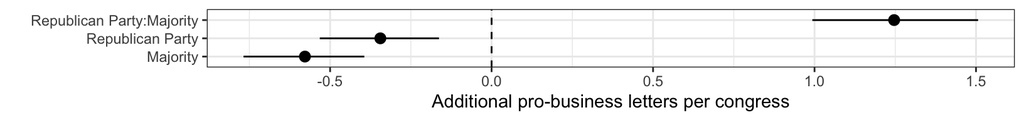

```r
# FIXME MOVE UP
letters_money %<>% mutate(Majority = majority == "Majority",
                          Majority = as.numeric(Majority))

mProPartyx <- glm(ProBusiness_Letters ~ party_name*Majority,
                 data = letters_money %>%
                   filter(industry == "energy") %>%
                   filter(party_name != "Independent") %>%
                   select(icpsr, congress, party_name, Majority, chamber,ProBusiness_Letters, PAC_100k) %>%
              distinct(),
            family = poisson)

# tidy(mProParty)
mplot(mProPartyx) +
  labs(x="", y="Additional pro-business letters per congress")
```

### Pro-business letters ~ Party + PAC

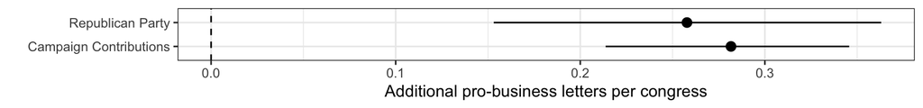

```r
# PAC + party:
mPro_pac_party <- glm(ProBusiness_Letters ~ PAC_100k + party_name,
                      data = letters_money %>%
                        filter(industry == "energy") %>%
                        filter(party_name != "Independent") %>%
                        select(icpsr, congress, PAC_100k, chamber,party_name, ProBusiness_Letters) %>%
              distinct(),
            family = poisson)

# tidy(mPro_pac_party)

mplot(mPro_pac_party)+
  labs(x="", y="Additional pro-business letters per congress")
```

```r
ratio(mPro_pac_party)
```

| party_name | PAC_100k | .fitted | ratio |
| --- | --- | --- | --- |
| Democratic Party | 0 | 0.1982883 | 1.000000 |
| Democratic Party | 1 | 0.2627949 | 1.325317 |
| Democratic Party | 2 | 0.3482865 | 1.756465 |
| Democratic Party | 3 | 0.4615901 | 2.327873 |
| Democratic Party | 4 | 0.6117532 | 3.085170 |
| Democratic Party | 5 | 0.8107669 | 4.088828 |
| Republican Party | 0 | 0.2566010 | 1.000000 |
| Republican Party | 1 | 0.3400777 | 1.325317 |
| Republican Party | 2 | 0.4507108 | 1.756465 |
| Republican Party | 3 | 0.5973347 | 2.327873 |
| Republican Party | 4 | 0.7916578 | 3.085170 |
| Republican Party | 5 | 1.0491976 | 4.088828 |

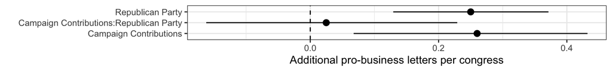

```r
# PAC*party interaction:
mPro_pacXparty <- glm(ProBusiness_Letters ~ PAC_100k * party_name,
                      data = letters_money %>%
                        filter(industry == "energy") %>%
                        filter(party_name != "Independent") %>%
                        select(icpsr, congress, PAC_100k, chamber,party_name, ProBusiness_Letters) %>%
                      distinct(),
            family = poisson)

# tidy(mPro_pacXparty)

mplot(mPro_pacXparty)+
  labs(x="", y="Additional pro-business letters per congress")
```

```r
ratio(mPro_pacXparty)
```

| party_name | PAC_100k | .fitted | ratio |
| --- | --- | --- | --- |
| Democratic Party | 0 | 0.1993937 | 1.000000 |
| Democratic Party | 1 | 0.2586207 | 1.297035 |
| Democratic Party | 2 | 0.3354401 | 1.682300 |
| Democratic Party | 3 | 0.4350776 | 2.182002 |
| Democratic Party | 4 | 0.5643109 | 2.830134 |
| Democratic Party | 5 | 0.7319311 | 3.670783 |
| Republican Party | 0 | 0.2560484 | 1.000000 |
| Republican Party | 1 | 0.3404762 | 1.329734 |
| Republican Party | 2 | 0.4527428 | 1.768192 |
| Republican Party | 3 | 0.6020274 | 2.351225 |
| Republican Party | 4 | 0.8005363 | 3.126504 |
| Republican Party | 5 | 1.0645002 | 4.157418 |

```r
# DW NOMINATE
#mPro_nominate <-glm(ProBusiness_Letters ~  nominate.dim1, data = letters_money %>% filter(!party %in% c("NA","(I)", "Independent"))%>% mutate(PAC_contributions = PAC_contributions/100000), family = "poisson" )
#tidy(mPro_nominate)
#mplot(mPro_nominate)+labs(x="", y="Additional letters per congress")

# PAC + ideology:
# mPro_pac_nominate <-glm(ProBusiness_Letters ~ PAC_contributions * nominate.dim1, data = letters_money %>% filter(!party %in% c("NA","(I)", "Independent"))%>% mutate(PAC_contributions = PAC_contributions/100000), family = "poisson" )

# tidy(mPro_pac_nominate)

# mplot(mPro_pac_nominate)+ labs(x="", y="Additional letters per congress")
```

### Multivariate models

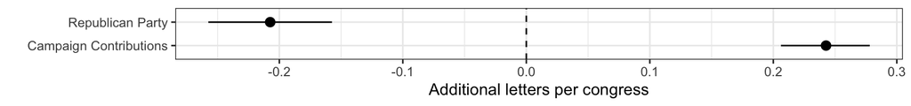

```r
# Full model, all letters
mAll_Full <- glm(total_letters ~ PAC_100k + party_name,
                 data = letters_money %>%
                        filter(industry == "energy") %>%
                        filter(party_name != "Independent") %>%
                        select(icpsr, congress, PAC_100k, chamber,party_name, total_letters) %>%
                      distinct(),
            family = poisson)

# tidy(mAll_Full)

mplot(mAll_Full)+
  labs(x="", y="Additional letters per congress")
```

```r
ratio(mAll_Full)
```

| party_name | PAC_100k | .fitted | ratio |
| --- | --- | --- | --- |
| Democratic Party | 0 | 1.109746 | 1.000000 |
| Democratic Party | 1 | 1.414563 | 1.274673 |
| Democratic Party | 2 | 1.803105 | 1.624791 |
| Democratic Party | 3 | 2.298369 | 2.071077 |
| Democratic Party | 4 | 2.929669 | 2.639945 |
| Democratic Party | 5 | 3.734369 | 3.365066 |
| Republican Party | 0 | 0.901878 | 1.000000 |
| Republican Party | 1 | 1.149599 | 1.274673 |
| Republican Party | 2 | 1.465363 | 1.624791 |
| Republican Party | 3 | 1.867858 | 2.071077 |
| Republican Party | 4 | 2.380908 | 2.639945 |
| Republican Party | 5 | 3.034879 | 3.365066 |

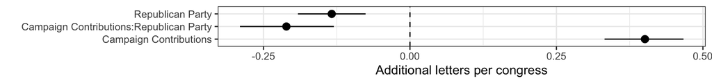

```r
# Full model with interaction:
mAll_Fullx <- glm(total_letters ~ PAC_100k*party_name,
                                   data = letters_money %>%
                        filter(industry == "energy") %>%
                        filter(party_name != "Independent") %>%
                        select(icpsr, congress, PAC_100k, chamber,party_name, total_letters) %>%
                      distinct(),
            family = poisson)
# tidy(mAll_Fullx)

mplot(mAll_Fullx)+
  labs(x="", y="Additional letters per congress")
```

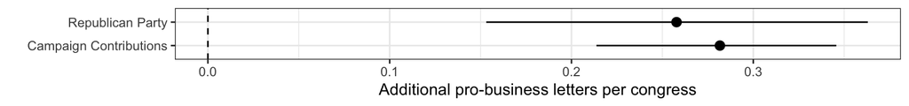

```r
# Full model, pro business letters
mPro_Full <- glm(ProBusiness_Letters ~ PAC_100k + party_name,
                                  data = letters_money %>%
                        filter(industry == "energy") %>%
                        filter(party_name != "Independent") %>%
                        select(icpsr, congress, PAC_100k, chamber,party_name, ProBusiness_Letters) %>%
                      distinct(),
            family = poisson)

# tidy(mPro_Full)

mplot(mPro_Full)+
  labs(x="", y="Additional pro-business letters per congress")
```

```r
ratio(mPro_Full)
```

| party_name | PAC_100k | .fitted | ratio |
| --- | --- | --- | --- |
| Democratic Party | 0 | 0.1982883 | 1.000000 |
| Democratic Party | 1 | 0.2627949 | 1.325317 |
| Democratic Party | 2 | 0.3482865 | 1.756465 |
| Democratic Party | 3 | 0.4615901 | 2.327873 |
| Democratic Party | 4 | 0.6117532 | 3.085170 |
| Democratic Party | 5 | 0.8107669 | 4.088828 |
| Republican Party | 0 | 0.2566010 | 1.000000 |
| Republican Party | 1 | 0.3400777 | 1.325317 |
| Republican Party | 2 | 0.4507108 | 1.756465 |
| Republican Party | 3 | 0.5973347 | 2.327873 |
| Republican Party | 4 | 0.7916578 | 3.085170 |
| Republican Party | 5 | 1.0491976 | 4.088828 |

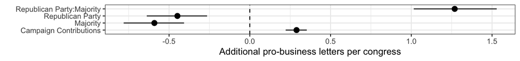

```r
# Full model, pro business letters with party majority
mPro_Fullpartyx <- glm(ProBusiness_Letters ~ PAC_100k + party_name*Majority,
                                  data = letters_money %>%
                        filter(industry == "energy") %>%
                        filter(party_name != "Independent") %>%
                        select(icpsr, congress, PAC_100k, chamber,party_name, ProBusiness_Letters, Majority) %>%
                      distinct(),
            family = poisson)

# tidy(mPro_Full)

mplot(mPro_Fullpartyx)+
  labs(x="", y="Additional pro-business letters per congress")
```

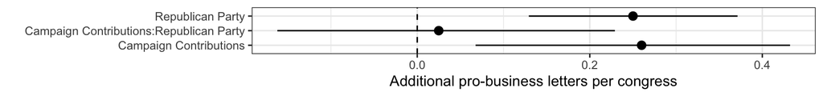

```r
# Full model with interaction:
mPro_Fullx <- glm(ProBusiness_Letters ~ PAC_100k * party_name,                                  data = letters_money %>%
                        filter(industry == "energy",
                               party_name != "Independent",
                               !is.na(ProBusiness_Letters)) %>%
                        select(icpsr, congress, PAC_100k, chamber,party_name, ProBusiness_Letters, Majority) %>%
                      distinct(),
            family = poisson)

# tidy(mPro_Fullx)

mplot(mPro_Fullx)+
  labs(x="", y="Additional pro-business letters per congress")
```

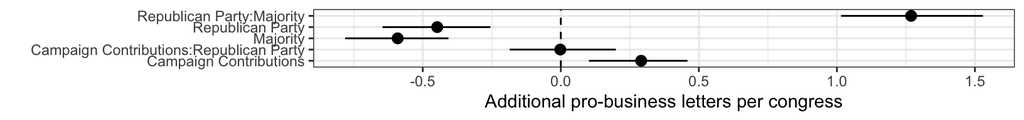

```r
# Full model with party interaction:
mPro_Fullpartyx <- glm(ProBusiness_Letters ~ PAC_100k * party_name+
                  party_name*Majority,
                                  data = letters_money %>%
                        filter(industry == "energy",
                               party_name != "Independent",
                               !is.na(ProBusiness_Letters)) %>%
                        select(icpsr, congress, PAC_100k, chamber,party_name, ProBusiness_Letters, Majority) %>%
                      distinct(),
            family = poisson)

# tidy(mPro_Fullx)

mplot(mPro_Fullpartyx)+
  labs(x="", y="Additional pro-business letters per congress")
```

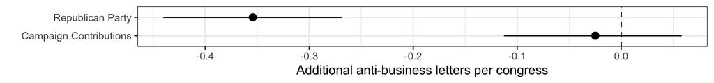

```r
# ANTI
mAnti_Full <- glm(AntiBusiness_Letters ~ PAC_100k + party_name,
                                  data = letters_money %>%
                        filter(industry == "energy") %>%
                        filter(party_name != "Independent") %>%
                    #mutate(PAC_100k = Log_PAC_contributions) %>% #fixme
                        select(icpsr, congress, PAC_100k, party_name,chamber, AntiBusiness_Letters) %>%
                      distinct(),
            family = poisson)

# tidy(mAnti_Full)

mplot(mAnti_Full)+
  labs(x="", y="Additional anti-business letters per congress")
```

```r
ratio(mAnti_Full)
```

| party_name | PAC_100k | .fitted | ratio |
| --- | --- | --- | --- |
| Democratic Party | 0 | 0.4532764 | 1.132718 |
| Democratic Party | 1 | 0.4421186 | 1.104835 |
| Democratic Party | 2 | 0.4312354 | 1.077638 |
| Democratic Party | 3 | 0.4206202 | 1.051111 |
| Democratic Party | 4 | 0.4102662 | 1.025237 |
| Democratic Party | 5 | 0.4001671 | 1.000000 |
| Republican Party | 0 | 0.3180703 | 1.132718 |
| Republican Party | 1 | 0.3102407 | 1.104835 |
| Republican Party | 2 | 0.3026038 | 1.077638 |
| Republican Party | 3 | 0.2951550 | 1.051111 |
| Republican Party | 4 | 0.2878894 | 1.025237 |
| Republican Party | 5 | 0.2808028 | 1.000000 |

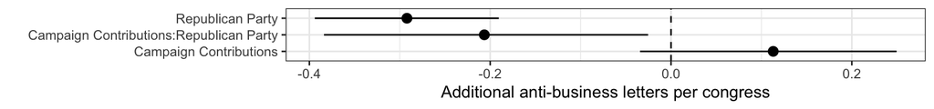

```r
# full model with interaction
mAnti_Fullx <- glm(AntiBusiness_Letters ~ PAC_100k * party_name,
                                  data = letters_money %>%
                        filter(industry == "energy") %>%
                        filter(party_name != "Independent") %>%
                        select(icpsr, congress, PAC_100k, party_name,chamber, AntiBusiness_Letters) %>%
                      distinct(),
            family = poisson)

# tidy(mAnti_Fullx)
mplot(mAnti_Fullx)+
  labs(x="", y="Additional anti-business letters per congress")
```

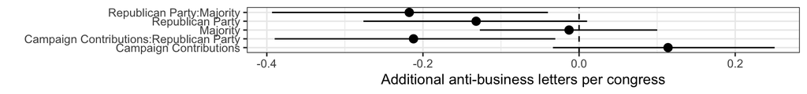

```r
# full model with party interaction
mAnti_Fullpartyx <- glm(AntiBusiness_Letters ~ PAC_100k * party_name + party_name*Majority,
                                  data = letters_money %>%
                        filter(industry == "energy") %>%
                        filter(party_name != "Independent") %>%
                        select(icpsr, congress, PAC_100k, party_name,chamber, AntiBusiness_Letters, Majority) %>%
                      distinct(),
            family = poisson)

# tidy(mAnti_Fullx)
mplot(mAnti_Fullpartyx)+
  labs(x="", y="Additional anti-business letters per congress")
```

```r
# FULL MODEL WITH NON- CONSTITUENT
# FIXME
#mNonConstituent_Fullx <- glm(NonConstituent_Letters ~ PAC_contributions*party, data = NonConstituent_letters_money %>% filter(!party %in% c("NA","(I)", "Independent"))%>% mutate(PAC_contributions = PAC_contributions/100000), family = "poisson" )
#tidy(mNonConstituent_Fullx)
#mplot(mNonConstituent_Fullx)+labs(x="", y="Additional non-constituent letters per congress")
```

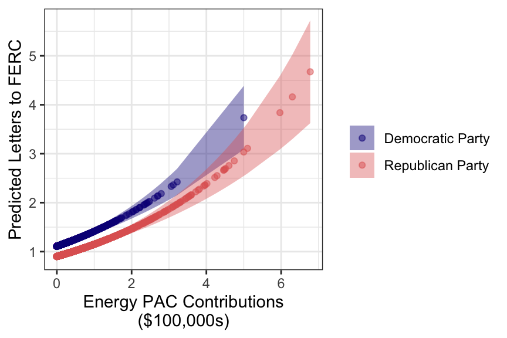

```r
mAll_Full %>% pplot()  +
  labs(y = "Predicted Letters to FERC")
```

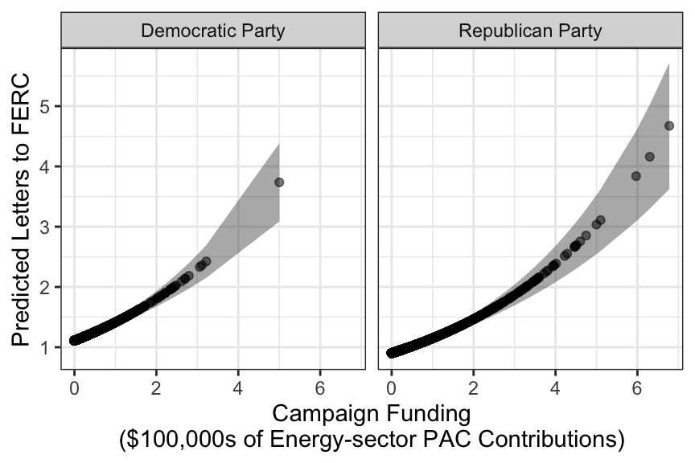

```r
mAll_Full %>% pplot2() +
  labs(y = "Predicted Letters to FERC")
```

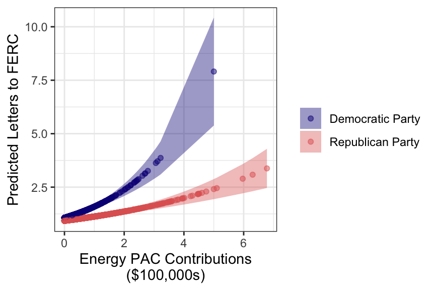

```r
mAll_Fullx %>% pplot()  +
  labs(y = "Predicted Letters to FERC")
```

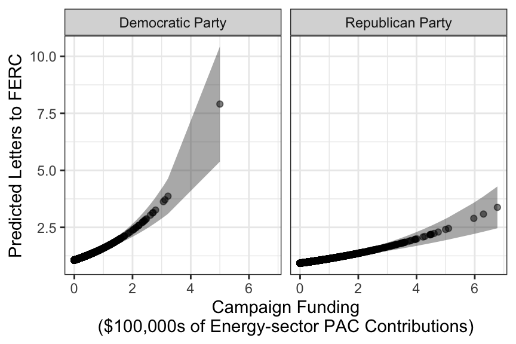

```r
mAll_Fullx %>% pplot2() +
  labs(y = "Predicted Letters to FERC")
```

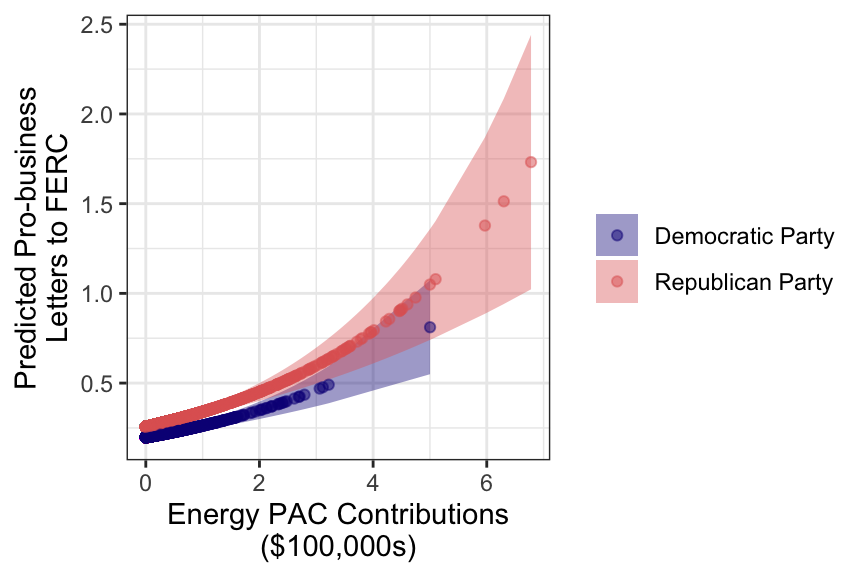

```r
mPro_Full %>% pplot()  +
  labs(y = "Predicted Pro-business\nLetters to FERC")
```

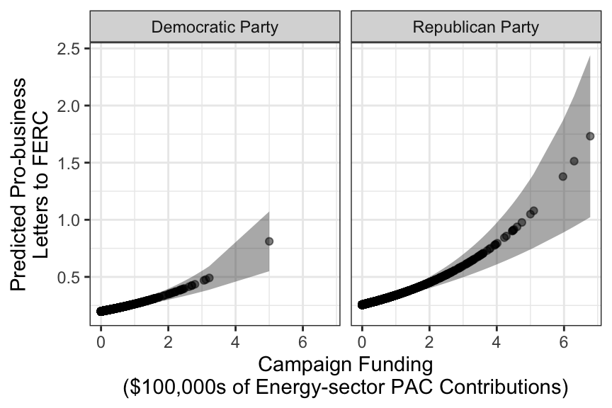

```r
mPro_Full %>% pplot2() +
  labs(y = "Predicted Pro-business\nLetters to FERC")
```

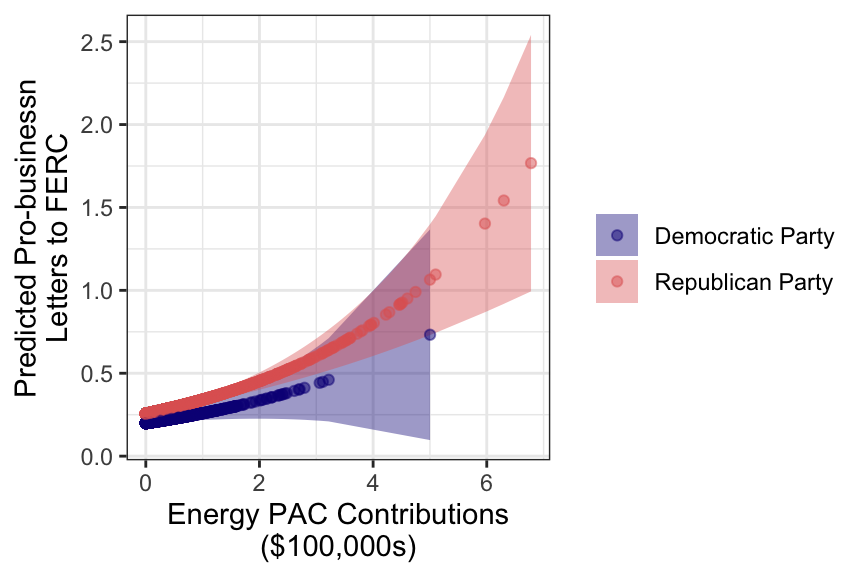

```r
mPro_Fullx %>% pplot()  +
  labs(y = "Predicted Pro-businessn\nLetters to FERC")
```

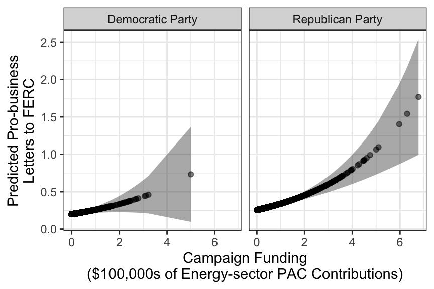

```r
mPro_Fullx %>% pplot2() +
  labs(y = "Predicted Pro-business\nLetters to FERC")
```

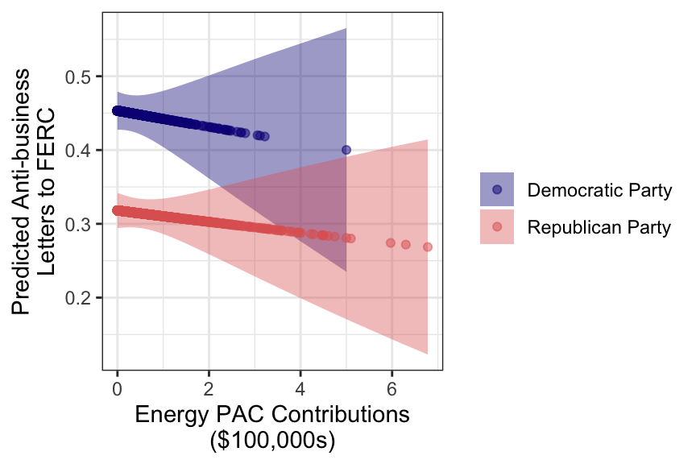

```r
mAnti_Full %>% pplot()  +
  labs(y = "Predicted Anti-business\nLetters to FERC")
```

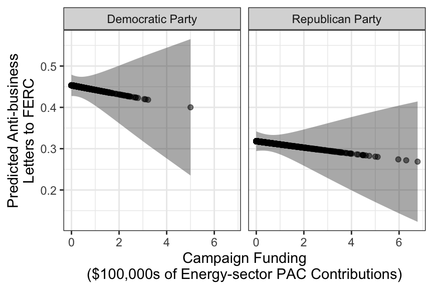

```r
mAnti_Full %>% pplot2() +
  labs(y = "Predicted Anti-business\nLetters to FERC")
```

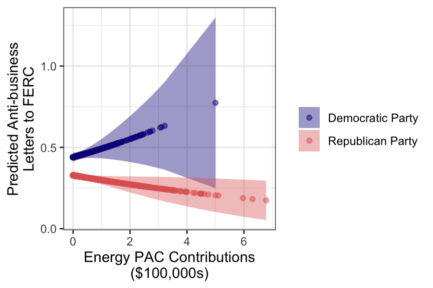

```r
mAnti_Fullx %>% pplot()  +
  labs(y = "Predicted Anti-business\nLetters to FERC")
```

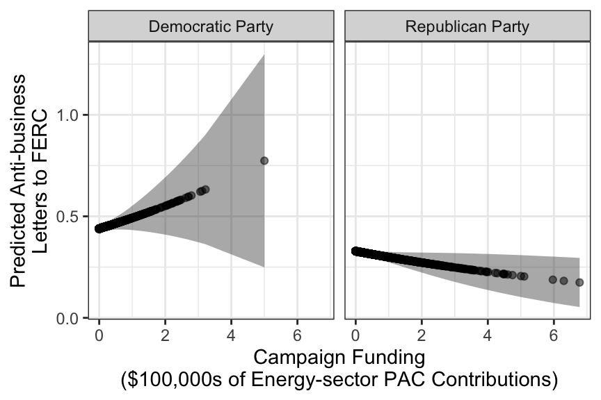

```r
mAnti_Fullx %>% pplot2() +
  labs(y = "Predicted Anti-business\nLetters to FERC")
```

### Multivariate logit

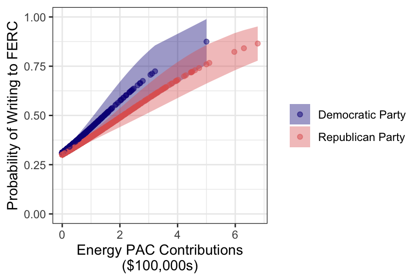

```r
# full logit
mAll_Fulllogit <- glm(total_letters>0 ~ PAC_100k*party_name,
                 data = letters_money %>%
                        filter(industry == "energy") %>%
                        filter(party_name != "Independent") %>%
                        distinct(icpsr, congress, PAC_100k, chamber,party_name, total_letters),
            family = binomial(link = "logit"))

mAll_Fulllogit %>% augment(type.predict = "response", se_fit = T, interval = "confidence") %>%
  ggplot() +
  aes(x = PAC_100k, y = .fitted,
      color = party_name, fill = party_name,
      ymax = .fitted + (1.96*.se.fit),
      ymin = .fitted - (1.96*.se.fit) ) +
    geom_ribbon(alpha = .4, color = NA)+
  geom_point(alpha = .5) +
  labs(x = "Energy PAC Contributions\n($100,000s)",
       y = "Probability of Writing to FERC",
       color = "",
       fill = "") +
  scale_y_continuous(limits = c(0,1)) +
  scale_fill_viridis_d(option = "plasma", end = .6) +
  scale_color_viridis_d(option = "plasma", end = .6)
```

```r
ratio(mAll_Fulllogit)
```

| party_name | PAC_100k | .fitted | ratio |
| --- | --- | --- | --- |
| Democratic Party | 0 | 0.3104129 | 1.000000 |
| Democratic Party | 1 | 0.4377222 | 1.410129 |
| Democratic Party | 2 | 0.5737987 | 1.848502 |
| Democratic Party | 3 | 0.6995477 | 2.253604 |
| Democratic Party | 4 | 0.8010586 | 2.580623 |
| Democratic Party | 5 | 0.8744292 | 2.816988 |
| Republican Party | 0 | 0.3015058 | 1.000000 |
| Republican Party | 1 | 0.3912332 | 1.297598 |
| Republican Party | 2 | 0.4889705 | 1.621761 |
| Republican Party | 3 | 0.5875584 | 1.948746 |
| Republican Party | 4 | 0.6795897 | 2.253985 |
| Republican Party | 5 | 0.7594914 | 2.518994 |

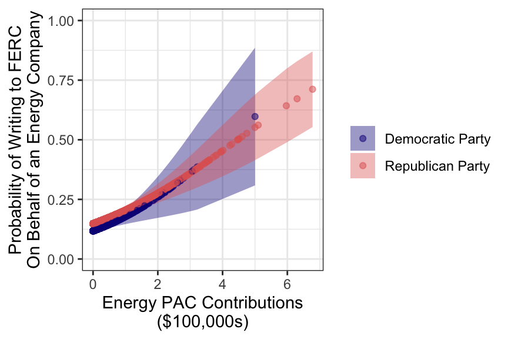

```r
# full logit pro
mpro_Fulllogit <- glm(ProBusiness_Letters>0 ~ PAC_100k *party_name,
                 data = letters_money %>%
                        filter(industry == "energy") %>%
                        filter(party_name != "Independent") %>%
                        distinct(icpsr, congress, PAC_100k, chamber,party_name, ProBusiness_Letters),
            family = binomial(link = "logit"))

mpro_Fulllogit %>% augment(type.predict = "response", se_fit = T, interval = "confidence") %>%
  ggplot() +
  aes(x = PAC_100k, y = .fitted,
      color = party_name, fill = party_name,
      ymax = .fitted + (1.96*.se.fit),
      ymin = .fitted - (1.96*.se.fit) ) +
    geom_ribbon(alpha = .4, color = NA)+
  geom_point(alpha = .5) +
  labs(x = "Energy PAC Contributions\n($100,000s)",
       y = "Probability of Writing to FERC\nOn Behalf of an Energy Company",
       color = "",
       fill = "") +
  scale_y_continuous(limits = c(0,1))+
  scale_fill_viridis_d(option = "plasma", end = .6) +
  scale_color_viridis_d(option = "plasma", end = .6)
```

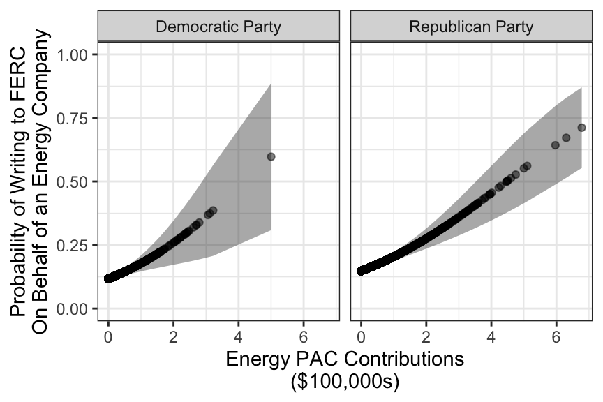

```r
mpro_Fulllogit %>% augment(type.predict = "response", se_fit = T, interval = "confidence") %>%
  ggplot() +
  aes(x = PAC_100k, y = .fitted,
      ymax = .fitted + (1.96*.se.fit),
      ymin = .fitted - (1.96*.se.fit) ) +
    geom_ribbon(alpha = .4, color = NA)+
  geom_point(alpha = .5) +
  labs(x = "Energy PAC Contributions\n($100,000s)",
       y = "Probability of Writing to FERC\nOn Behalf of an Energy Company",
       color = "",
       fill = "") +
  scale_y_continuous(limits = c(0,1))+
  scale_fill_viridis_d(option = "plasma", end = .6) +
  scale_color_viridis_d(option = "plasma", end = .6) +
  facet_grid(. ~ party_name)
```

```r
mpro_Fulllogit %>% ratio()
```

| party_name | PAC_100k | .fitted | ratio |
| --- | --- | --- | --- |
| Democratic Party | 0 | 0.1178661 | 1.000000 |
| Democratic Party | 1 | 0.1777773 | 1.508298 |
| Democratic Party | 2 | 0.2591934 | 2.199049 |
| Democratic Party | 3 | 0.3615021 | 3.067057 |
| Democratic Party | 4 | 0.4781300 | 4.056551 |
| Democratic Party | 5 | 0.5971920 | 5.066697 |
| Republican Party | 0 | 0.1481958 | 1.000000 |
| Republican Party | 1 | 0.2046546 | 1.380974 |
| Republican Party | 2 | 0.2756618 | 1.860118 |
| Republican Party | 3 | 0.3601497 | 2.430228 |
| Republican Party | 4 | 0.4542917 | 3.065482 |
| Republican Party | 5 | 0.5518193 | 3.723581 |

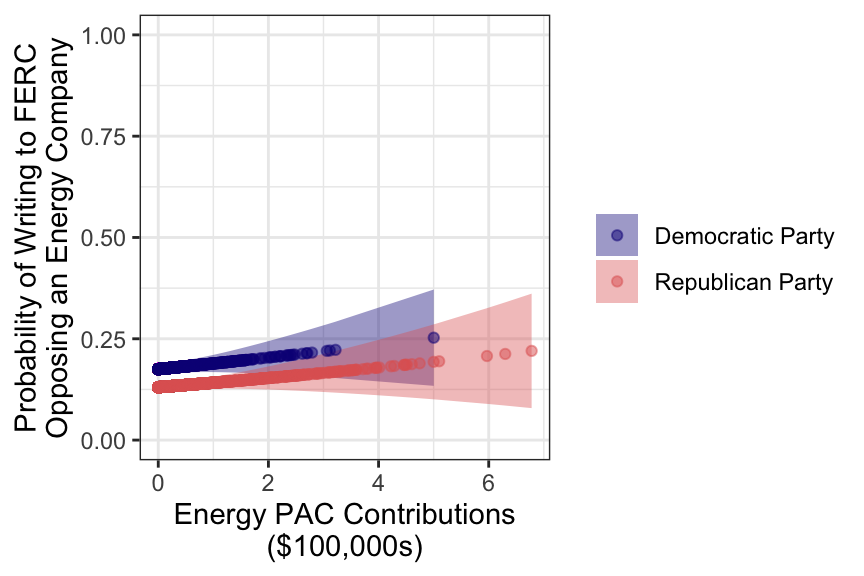

```r
# full anti logit
manti_Fulllogit <- glm(AntiBusiness_Letters>0 ~ PAC_100k +party_name,
                 data = letters_money %>%
                        filter(industry == "energy") %>%
                        filter(party_name != "Independent") %>%
                        distinct(icpsr, congress, PAC_100k, chamber,party_name, AntiBusiness_Letters),
            family = binomial(link = "logit"))

manti_Fulllogit %>% augment(type.predict = "response", se_fit = T, interval = "confidence") %>%
  ggplot() +
  aes(x = PAC_100k, y = .fitted,
      color = party_name, fill = party_name,
      ymax = .fitted + (1.96*.se.fit),
      ymin = .fitted - (1.96*.se.fit) ) +
    geom_ribbon(alpha = .4, color = NA)+
  geom_point(alpha = .5) +
  labs(x = "Energy PAC Contributions\n($100,000s)",
       y = "Probability of Writing to FERC\nOpposing an Energy Company",
       color = "",
       fill = "") +
  scale_y_continuous(limits = c(0,1)) +
  scale_fill_viridis_d(option = "plasma", end = .6) +
  scale_color_viridis_d(option = "plasma", end = .6)
```

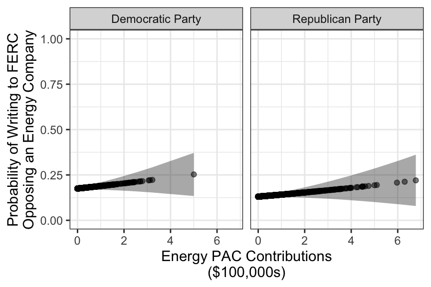

```r
manti_Fulllogit %>% augment(type.predict = "response", se_fit = T, interval = "confidence") %>%
  ggplot() +
  aes(x = PAC_100k, y = .fitted,
      ymax = .fitted + (1.96*.se.fit),
      ymin = .fitted - (1.96*.se.fit) ) +
    geom_ribbon(alpha = .4, color = NA)+
  geom_point(alpha = .5) +
  labs(x = "Energy PAC Contributions\n($100,000s)",
       y = "Probability of Writing to FERC\nOpposing an Energy Company",
       color = "",
       fill = "") +
  scale_y_continuous(limits = c(0,1)) +
  scale_fill_viridis_d(option = "plasma", end = .6) +
  scale_color_viridis_d(option = "plasma", end = .6) +
  facet_grid(. ~party_name)
```

```r
ratio(manti_Fulllogit)
```

| party_name | PAC_100k | .fitted | ratio |
| --- | --- | --- | --- |
| Democratic Party | 0 | 0.1751780 | 1.000000 |
| Democratic Party | 1 | 0.1890244 | 1.079042 |
| Democratic Party | 2 | 0.2036950 | 1.162789 |
| Democratic Party | 3 | 0.2191965 | 1.251279 |
| Democratic Party | 4 | 0.2355287 | 1.344511 |
| Democratic Party | 5 | 0.2526841 | 1.442442 |
| Republican Party | 0 | 0.1306366 | 1.000000 |
| Republican Party | 1 | 0.1415666 | 1.083668 |
| Republican Party | 2 | 0.1532500 | 1.173102 |
| Republican Party | 3 | 0.1657114 | 1.268492 |
| Republican Party | 4 | 0.1789719 | 1.369999 |
| Republican Party | 5 | 0.1930481 | 1.477749 |

### Average Pro-Business letters per cycle ~ total Energy Sector PAC contributions 1990-2014

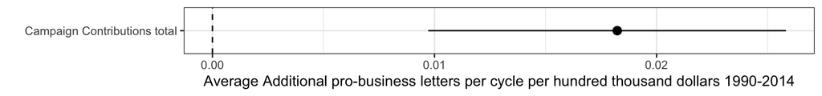

```r
# many fewer observations over time period (about 1000 members served)
mProTotal <- glm(ProBusiness_Letters_Per_Cycle ~ PAC_100k_total,
                                  data = letters_money %>%
                        filter(industry == "energy") %>%
                        filter(party_name != "Independent") %>%
                        select(icpsr,PAC_contributions_total, ProBusiness_Letters_Per_Cycle) %>%
                   mutate(PAC_100k_total = PAC_contributions_total/100000) %>%
                      distinct(),
            family = poisson)

# tidy(mProTotal)
mplot(mProTotal)+
  labs(x="", y="Average Additional pro-business letters per cycle per hundred thousand dollars 1990-2014")
```

```r
newdata_total <- expand(letters_money,
                   party_name,
                   PAC_100k_total = seq(0,5))

mProTotal %>% augment(type.predict = "response", se_fit = T, interval = "confidence", newdata = newdata_total) %>%
  group_by(party_name) %>%
  mutate(ratio = .fitted/min(.fitted)) %>% kable()
```

| party_name | PAC_100k_total | .fitted | .se.fit | ratio |
| --- | --- | --- | --- | --- |
| Democratic Party | 0 | 0.2099543 | 0.0141073 | 1.000000 |
| Democratic Party | 1 | 0.2138166 | 0.0139092 | 1.018396 |
| Democratic Party | 2 | 0.2177499 | 0.0137413 | 1.037130 |
| Democratic Party | 3 | 0.2217556 | 0.0136097 | 1.056209 |
| Democratic Party | 4 | 0.2258350 | 0.0135207 | 1.075639 |
| Democratic Party | 5 | 0.2299894 | 0.0134812 | 1.095426 |
| Republican Party | 0 | 0.2099543 | 0.0141073 | 1.000000 |
| Republican Party | 1 | 0.2138166 | 0.0139092 | 1.018396 |
| Republican Party | 2 | 0.2177499 | 0.0137413 | 1.037130 |
| Republican Party | 3 | 0.2217556 | 0.0136097 | 1.056209 |
| Republican Party | 4 | 0.2258350 | 0.0135207 | 1.075639 |
| Republican Party | 5 | 0.2299894 | 0.0134812 | 1.095426 |

## Anti-Business Letters per cycle ~ Energy Sector PAC contributions per cycle 1998-2014

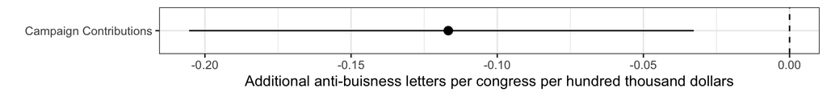

```r
mAnti <- glm(AntiBusiness_Letters ~ PAC_100k,
                                  data = letters_money %>%
                        filter(industry == "energy") %>%
                        filter(party_name != "Independent") %>%
               #mutate(PAC_100k = Log_PAC_contributions) %>% #fixme
                        select(icpsr, congress,party_name, chamber,PAC_100k, AntiBusiness_Letters) %>%
                      distinct(),
            family = poisson)
# tidy(mAnti)
mAnti %>% mplot()+
  labs(x="", y="Additional anti-buisness letters per congress per hundred thousand dollars")
```

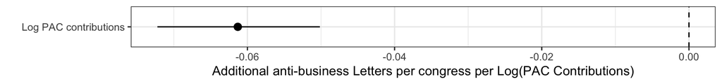

```r
mAntiLog <- glm(AntiBusiness_Letters ~ Log_PAC_contributions,
                                  data = letters_money %>%
                        filter(industry == "energy") %>%
                        # filter(party_name != "Independent") %>%
                        select(icpsr,congress,party_name, chamber,Log_PAC_contributions, AntiBusiness_Letters) %>%
                      distinct(),
            family = poisson)
# tidy(mAntiLog)
mAntiLog %>% mplot()+
  labs(x="", y="Additional anti-business Letters per congress per Log(PAC Contributions)")
```

```r
mAnti %>% augment(type.predict = "response", se_fit = T, interval = "confidence", newdata = newdata) %>%
  group_by(party_name) %>%
  mutate(ratio = .fitted/min(.fitted)) %>% kable()
```

| party_name | PAC_100k | .fitted | .se.fit | ratio |
| --- | --- | --- | --- | --- |
| Democratic Party | 0 | 0.3963022 | 0.0100200 | 1.792717 |
| Democratic Party | 1 | 0.3526340 | 0.0128480 | 1.595179 |
| Democratic Party | 2 | 0.3137776 | 0.0240877 | 1.419407 |
| Democratic Party | 3 | 0.2792027 | 0.0334301 | 1.263004 |
| Democratic Party | 4 | 0.2484375 | 0.0405623 | 1.123834 |
| Democratic Party | 5 | 0.2210624 | 0.0457632 | 1.000000 |
| Republican Party | 0 | 0.3963022 | 0.0100200 | 1.792717 |
| Republican Party | 1 | 0.3526340 | 0.0128480 | 1.595179 |
| Republican Party | 2 | 0.3137776 | 0.0240877 | 1.419407 |
| Republican Party | 3 | 0.2792027 | 0.0334301 | 1.263004 |
| Republican Party | 4 | 0.2484375 | 0.0405623 | 1.123834 |
| Republican Party | 5 | 0.2210624 | 0.0457632 | 1.000000 |

#### Anti-business letters by party

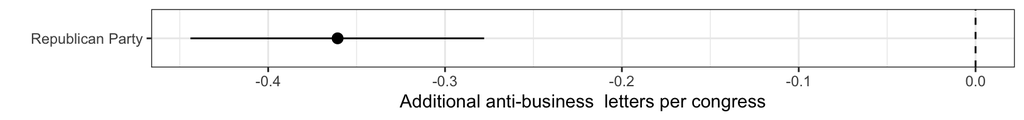

```r
mAntiParty <- glm(AntiBusiness_Letters ~ party_name,
                                  data = letters_money %>%
                        filter(industry == "energy") %>%
                        filter(party_name != "Independent") %>%
                        select(icpsr, congress, PAC_100k, chamber,AntiBusiness_Letters, party_name) %>%
                      distinct(),
            family = poisson)
# tidy(mAntiParty)
mplot(mAntiParty) +
  labs(x="", y="Additional anti-business  letters per congress")
```

```r
mAntiParty %>% ratio()
```

| party_name | PAC_100k | .fitted | ratio |
| --- | --- | --- | --- |
| Democratic Party | 0 | 0.4508532 | 1 |
| Democratic Party | 1 | 0.4508532 | 1 |
| Democratic Party | 2 | 0.4508532 | 1 |
| Democratic Party | 3 | 0.4508532 | 1 |
| Democratic Party | 4 | 0.4508532 | 1 |
| Democratic Party | 5 | 0.4508532 | 1 |
| Republican Party | 0 | 0.3143137 | 1 |
| Republican Party | 1 | 0.3143137 | 1 |
| Republican Party | 2 | 0.3143137 | 1 |
| Republican Party | 3 | 0.3143137 | 1 |
| Republican Party | 4 | 0.3143137 | 1 |
| Republican Party | 5 | 0.3143137 | 1 |

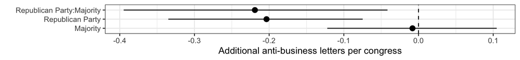

```r
mAntiPartyx <- glm(AntiBusiness_Letters ~ party_name*Majority,
                 data = letters_money %>%
                   filter(industry == "energy") %>%
                   filter(party_name != "Independent") %>%
                   mutate(Majority = majority == "Majority",
                          Majority = as.numeric(Majority)) %>%
                   select(icpsr, congress, party_name, Majority, chamber,AntiBusiness_Letters, PAC_100k) %>%
              distinct(),
            family = poisson)

# tidy(mProParty)
mplot(mAntiPartyx) +
  labs(x="", y="Additional anti-business letters per congress")
```

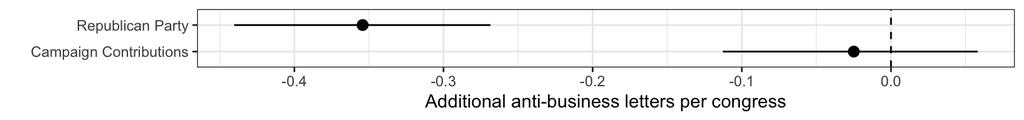

```r
#PAC*party interaction:
mAnti_pac_party <- glm(AntiBusiness_Letters ~ PAC_100k + party_name,
                                  data = letters_money %>%
                        filter(industry == "energy") %>%
                        filter(party_name != "Independent") %>%
                        select(icpsr,congress,PAC_100k, chamber,AntiBusiness_Letters, party_name) %>%
                      distinct(),
            family = poisson)

# tidy(mAnti_pac_party)
mplot(mAnti_pac_party)+ labs(x="", y="Additional anti-business letters per congress")
```

```r
ratio(mAnti_pac_party)
```

| party_name | PAC_100k | .fitted | ratio |
| --- | --- | --- | --- |
| Democratic Party | 0 | 0.4532764 | 1.132718 |
| Democratic Party | 1 | 0.4421186 | 1.104835 |
| Democratic Party | 2 | 0.4312354 | 1.077638 |
| Democratic Party | 3 | 0.4206202 | 1.051111 |
| Democratic Party | 4 | 0.4102662 | 1.025237 |
| Democratic Party | 5 | 0.4001671 | 1.000000 |
| Republican Party | 0 | 0.3180703 | 1.132718 |
| Republican Party | 1 | 0.3102407 | 1.104835 |
| Republican Party | 2 | 0.3026038 | 1.077638 |
| Republican Party | 3 | 0.2951550 | 1.051111 |
| Republican Party | 4 | 0.2878894 | 1.025237 |
| Republican Party | 5 | 0.2808028 | 1.000000 |

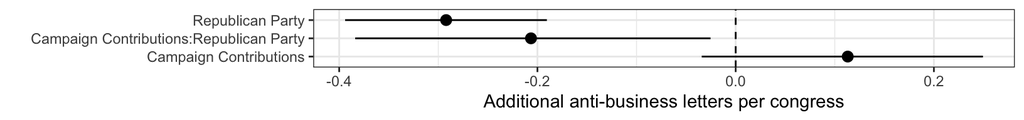

```r
#PAC*party interaction:
mAnti_pacXparty <- glm(AntiBusiness_Letters ~ PAC_100k*party_name,
                                  data = letters_money %>%
                        filter(industry == "energy") %>%
                        filter(party_name != "Independent") %>%
                        select(icpsr, congress,chamber,PAC_100k, AntiBusiness_Letters, party_name) %>%
                      distinct(),
            family = poisson)

# tidy(mAnti_pacXparty)

# FIXME odd error
mplot(mAnti_pacXparty)+ labs(x="", y="Additional anti-business letters per congress")
```

#### Average Anti-Business letters per cycle ~ total Energy Sector PAC contributions 1990-2014

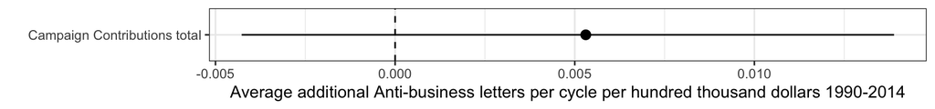

```r
mAntiTotal <- glm(AntiBusiness_Letters_Per_Cycle ~ PAC_100k_total,
                                  data = letters_money %>%
                        filter(industry == "energy") %>%
                        filter(party_name != "Independent") %>%
                        select(icpsr, PAC_contributions_total, AntiBusiness_Letters_Per_Cycle) %>%
                   mutate(PAC_100k_total = PAC_contributions_total/100000) %>%
                      distinct(),
            family = poisson)

# tidy(mProTotal)
mplot(mAntiTotal)+
  labs(x="", y="Average additional Anti-business letters per cycle per hundred thousand dollars 1990-2014")
```

# Combined models

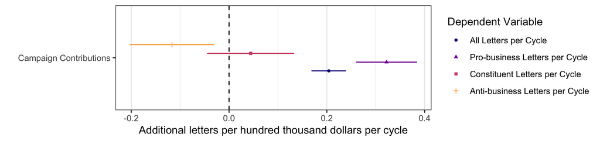

```r
library(dplyr)
dplot <- function(x){dwplot(x %>%
                              mutate(term = str_remove(term, "party_name") %>%
                                       str_replace("PAC_100k", "Campaign Contributions"))
                            ) +
    aes(shape = model) +
    geom_vline(xintercept = 0, linetype = 2) +
    scale_color_viridis_d(option = "C", end = .8) +
    labs(color = "Dependent Variable",
         shape = "Dependent Variable") +
  theme(panel.grid.major.y  = element_blank())
}

# Basic PAC money models
models <- full_join(
  tidy(mAll) %>% mutate(model = "All Letters per Cycle"),
  tidy(mPro) %>% mutate(model = "Pro-business Letters per Cycle") ) %>%
  full_join(tidy(mConstituent) %>% mutate(model = "Constituent Letters per Cycle")) %>%
  full_join(tidy(mAnti)  %>% mutate(model = "Anti-business Letters per Cycle"))

dplot(models)+
    labs(color = "Dependent Variable",
         shape = "Dependent Variable",
         x = "Additional letters per hundred thousand dollars per cycle")
```

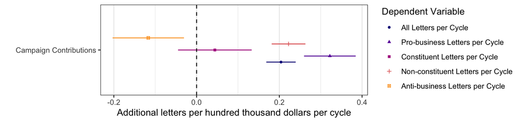

```r
library(stargazer)
library(dplyr)
write_lines(
  stargazer(mAll, mPro, mAnti, mConstituent,
            covariate.labels = c("Campaign Contributions (per 100k)", "Republican"),
          dep.var.caption  = "Letters to FERC",
          dep.var.labels   = c("Total", "Pro-business", "Anti-business", "Constituent"),
            float=F),
  path = here("FERC/tables/All-mPro-mAnti-mConstituent.tex"))

table <- stargazer(mAll, mPro, mAnti, mNonConstituent,
                               covariate.labels = c("Campaign Contributions (per 100k)", "Republican"),
          dep.var.caption  = "Letters to FERC",
          dep.var.labels   = c("Total", "Pro-business", "Anti-business", "Constituent"),
                type = "html",
                notes = "FERC/tables/All-mPro-mAnti-mConstituent.tex")

# with non-constituents
models <- full_join(
  tidy(mAll) %>% mutate(model = "All Letters per Cycle"),
  tidy(mPro) %>% mutate(model = "Pro-business Letters per Cycle") ) %>%
  full_join(tidy(mConstituent) %>% mutate(model = "Constituent Letters per Cycle")) %>%
  full_join(tidy(mNonConstituent) %>% mutate(model = "Non-constituent Letters per Cycle")) %>%
  full_join(tidy(mAnti)  %>% mutate(model = "Anti-business Letters per Cycle"))

dplot(models)+
    labs(color = "Dependent Variable",
         shape = "Dependent Variable",
         x = "Additional letters per hundred thousand dollars per cycle")
```

```r
library(stargazer)
library(dplyr)
write_lines(stargazer(mAll, mPro, mAnti, mConstituent, mNonConstituent,
            covariate.labels = c("Campaign Contributions (per 100k)"),
          dep.var.caption  = "Letters to FERC",
          dep.var.labels   = c("Total", "Pro-business", "Anti-business", "Constituent", "Non-constituent"),
            float=F),
  path = here("FERC/tables/All-mPro-mAnti-mNonConstituent.tex"))

table <- stargazer(mAll, mPro, mAnti, mNonConstituent,
                type = "html",
                notes = "FERC/tables/All-mPro-mAnti-mNonConstituent.tex")
```

```r
htmltools::HTML(table)
```

|  | *Dependent variable:* |  |  |  |
| --- | --- | --- | --- | --- |
|  | total_letters | ProBusiness_Letters | AntiBusiness_Letters | Non_Constituent_Letters |
|  | (1) | (2) | (3) | (4) |
| PAC_100k | 0.204*** | 0.322*** | -0.117*** | 0.222*** |
|  | (0.018) | (0.032) | (0.044) | (0.021) |
| Constant | 0.016 | -1.492*** | -0.926*** | -0.317*** |
|  | (0.015) | (0.030) | (0.025) | (0.017) |
| Observations | 5,997 | 5,997 | 5,997 | 5,997 |
| Log Likelihood | -12,606.460 | -4,212.596 | -6,183.930 | -9,761.498 |
| Akaike Inf. Crit. | 25,216.930 | 8,429.191 | 12,371.860 | 19,527.000 |
| *Note:* | *p<0.1; **p<0.05; ***p<0.01 |  |  |  |
|  | FERC/tables/All-mPro-mAnti-mNonConstituent.tex |  |  |  |

### logged PAC money models

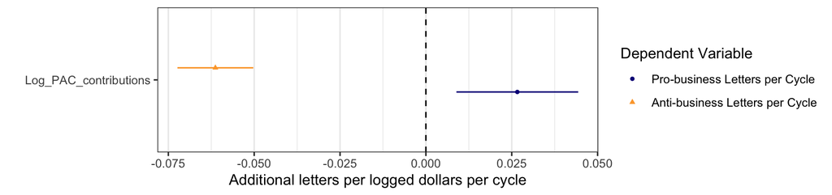

```r
## logged PAC money models
models <- tidy(mProLog) %>% mutate(model = "Pro-business Letters per Cycle") %>%
full_join(tidy(mAntiLog) %>% mutate(model = "Anti-business Letters per Cycle"))

dplot(models)+
    labs(x = "Additional letters per logged dollars per cycle")
```

```r
write_lines(
  stargazer::stargazer(mProLog, mAntiLog,
                                   covariate.labels = c("Log Campaign Contributions"),
          dep.var.caption  = "Letters to FERC",
          dep.var.labels   = c("Pro-business", "Anti-business"),
                       float=F),
  path = here("FERC/tables/mProLog-mAntiLog.tex"))

table <- stargazer(mProLog, mAntiLog,
                type = "html",
                notes = "FERC/tables/mProLog-mAntiLog.tex")
```

```r
htmltools::HTML(table)
```

|  | *Dependent variable:* |  |
| --- | --- | --- |
|  | ProBusiness_Letters | AntiBusiness_Letters |
|  | (1) | (2) |
| Log_PAC_contributions | 0.027*** | -0.061*** |
|  | (0.009) | (0.006) |
| Constant | -1.601*** | -0.435*** |
|  | (0.087) | (0.051) |
| Observations | 5,997 | 5,997 |
| Log Likelihood | -4,247.016 | -6,135.061 |
| Akaike Inf. Crit. | 8,498.032 | 12,274.120 |
| *Note:* | *p<0.1; **p<0.05; ***p<0.01 |  |
|  | FERC/tables/mProLog-mAntiLog.tex |  |

### PAC contributions over entire time period

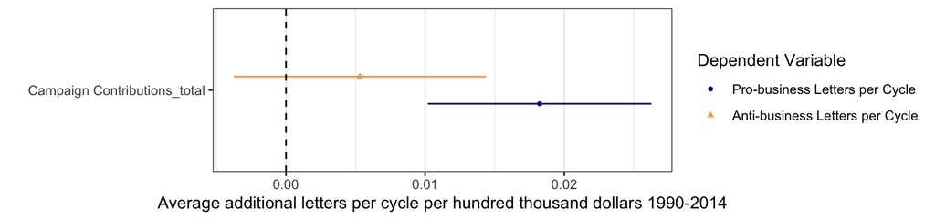

```r
## PAC contributions over entire time period
models <- tidy(mProTotal) %>%
  mutate(model = "Pro-business Letters per Cycle") %>%
  full_join(tidy(mAntiTotal) %>% mutate(model = "Anti-business Letters per Cycle"))

dplot(models) +
    labs(x = "Average additional letters per cycle per hundred thousand dollars 1990-2014")
```

```r
write_lines(
  stargazer::stargazer(mProTotal, mAntiTotal,             covariate.labels = c("Career Total Campaign Contributions (per 100k)"),
          dep.var.caption  = "Career Average Letters to FERC",
          dep.var.labels   = c("Pro-business", "Anti-business"),
          float=F),
  path = here("FERC/tables/mProTotal-mAntiTotal.tex"))

table <- stargazer(mProTotal, mAntiTotal,
                   covariate.labels = c("Career Total Campaign Contributions (per 100k)"),
          dep.var.caption  = "Career Total Letters to FERC",
          dep.var.labels   = c("Pro-business", "Anti-business"),
                type = "html",
                notes = "FERC/tables/mProTotal-mAntiTotal.tex")
```

```r
htmltools::HTML(table)
```

|  | Career Total Letters to FERC |  |
| --- | --- | --- |
|  | Pro-business | Anti-business |
|  | (1) | (2) |
| Career Total Campaign Contributions (per 100k) | 0.018*** | 0.005 |
|  | (0.004) | (0.005) |
| Constant | -1.561*** | -1.189*** |
|  | (0.067) | (0.059) |
| Observations | 1,306 | 1,306 |
| Log Likelihood | -Inf.000 | -Inf.000 |
| Akaike Inf. Crit. | Inf.000 | Inf.000 |
| *Note:* | *p<0.1; **p<0.05; ***p<0.01 |  |
|  | FERC/tables/mProTotal-mAntiTotal.tex |  |

### Party

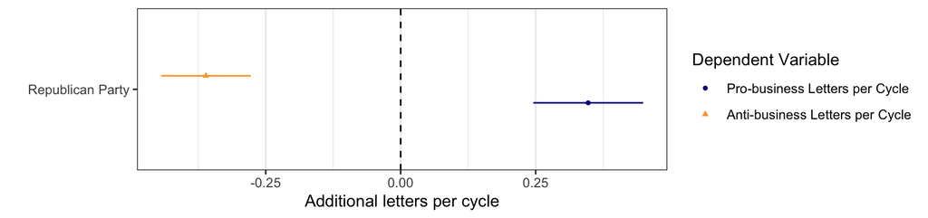

```r
## With party IV
models <- tidy(mProParty) %>%
  mutate(model = "Pro-business Letters per Cycle") %>%
  full_join(tidy(mAntiParty) %>%
              mutate(model = "Anti-business Letters per Cycle")) %>%
  # mutate(term = str_replace(term, "party\\(R\\)", "Republican")) %>%
  filter(term != "party(I)")

dplot(models) +
    labs(x = "Additional letters per cycle")
```

```r
write_lines(
  stargazer::stargazer(mProParty, mAntiParty,
                                   covariate.labels = c("Republican"),
          dep.var.caption  = "Letters to FERC",
          dep.var.labels   = c( "Pro-business", "Anti-business"),
          float=F),
  path = here("FERC/tables/mProParty-mAntiParty.tex"))

table <- stargazer(mProParty, mAntiParty,
                type = "html",
                notes = "FERC/tables/mProParty-mAntiParty.tex")
```

```r
htmltools::HTML(table)
```

|  | *Dependent variable:* |  |
| --- | --- | --- |
|  | ProBusiness_Letters | AntiBusiness_Letters |
|  | (1) | (2) |
| party_nameRepublican Party | 0.347*** | -0.361*** |
|  | (0.052) | (0.042) |
| Constant | -1.551*** | -0.797*** |
|  | (0.040) | (0.028) |
| Observations | 5,997 | 5,997 |
| Log Likelihood | -4,228.850 | -6,150.971 |
| Akaike Inf. Crit. | 8,461.700 | 12,305.940 |
| *Note:* | *p<0.1; **p<0.05; ***p<0.01 |  |
|  | FERC/tables/mProParty-mAntiParty.tex |  |

### Univariate models

```r
# All models
write_lines(
  stargazer::stargazer(mAll, mPro, mAnti, mConstituent, mNonConstituent, mProLog, mAntiLog, mProParty, mAntiParty, mProTotal, mAntiTotal,
                       covariate.labels = c("Campaign Contributions (per 100k)"),
          dep.var.caption  = "Letters to FERC",
          dep.var.labels   = c("Total", "Pro-business", "Anti-business",
                               "Constituent",
                               "Non-constituent", "Log(Pro-business+1)",
                               "Log(Anti-business+1)",
                               "Pro-business",
                               "Anti-business",
                               "Pro-business (career total)",
                               "Anti-business (career total"),
          float=F),
  path = here("FERC/tables/mUnivariate.tex"))

table <-stargazer(mAll, mPro, mAnti,mConstituent, mNonConstituent, mProLog, mAntiLog, mProParty, mAntiParty, mProTotal, mAntiTotal,
                type = "html",
                notes = "FERC/tables/mUnivariate.tex")
```

```r
htmltools::HTML(table)
```

|  | *Dependent variable:* |  |  |  |  |  |  |  |  |  |  |
| --- | --- | --- | --- | --- | --- | --- | --- | --- | --- | --- | --- |
|  | total_letters | ProBusiness_Letters | AntiBusiness_Letters | Constituent_Letters | Non_Constituent_Letters | ProBusiness_Letters | AntiBusiness_Letters | ProBusiness_Letters | AntiBusiness_Letters | ProBusiness_Letters_Per_Cycle | AntiBusiness_Letters_Per_Cycle |
|  | (1) | (2) | (3) | (4) | (5) | (6) | (7) | (8) | (9) | (10) | (11) |
| PAC_100k | 0.204*** | 0.322*** | -0.117*** | 0.044 | 0.222*** |  |  |  |  |  |  |
|  | (0.018) | (0.032) | (0.044) | (0.045) | (0.021) |  |  |  |  |  |  |
| Log_PAC_contributions |  |  |  |  |  | 0.027*** | -0.061*** |  |  |  |  |
|  |  |  |  |  |  | (0.009) | (0.006) |  |  |  |  |
| party_nameRepublican Party |  |  |  |  |  |  |  | 0.347*** | -0.361*** |  |  |
|  |  |  |  |  |  |  |  | (0.052) | (0.042) |  |  |
| PAC_100k_total |  |  |  |  |  |  |  |  |  | 0.018*** | 0.005 |
|  |  |  |  |  |  |  |  |  |  | (0.004) | (0.005) |
| Constant | 0.016 | -1.492*** | -0.926*** | -1.373*** | -0.317*** | -1.601*** | -0.435*** | -1.551*** | -0.797*** | -1.561*** | -1.189*** |
|  | (0.015) | (0.030) | (0.025) | (0.030) | (0.017) | (0.087) | (0.051) | (0.040) | (0.028) | (0.067) | (0.059) |
| Observations | 5,997 | 5,997 | 5,997 | 5,997 | 5,997 | 5,997 | 5,997 | 5,997 | 5,997 | 1,306 | 1,306 |
| Log Likelihood | -12,606.460 | -4,212.596 | -6,183.930 | -4,795.028 | -9,761.498 | -4,247.016 | -6,135.061 | -4,228.850 | -6,150.971 | -Inf.000 | -Inf.000 |
| Akaike Inf. Crit. | 25,216.930 | 8,429.191 | 12,371.860 | 9,594.055 | 19,527.000 | 8,498.032 | 12,274.120 | 8,461.700 | 12,305.940 | Inf.000 | Inf.000 |
| *Note:* | *p<0.1; **p<0.05; ***p<0.01 |  |  |  |  |  |  |  |  |  |  |
|  | FERC/tables/mUnivariate.tex |  |  |  |  |  |  |  |  |  |  |

### Multivariate Models

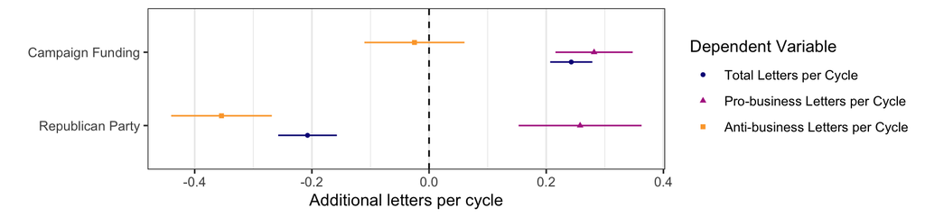

```r
## Full models
models <- tidy(mAll_Full) %>%
  mutate(model = "Total Letters per Cycle") %>%
  full_join(tidy(mPro_Full) %>%
              mutate(model = "Pro-business Letters per Cycle")) %>%
  full_join(tidy(mAnti_Full) %>%
              mutate(model = "Anti-business Letters per Cycle")) %>%
  mutate(term = str_replace(term, "PAC_100k", "Campaign Funding"))# %>%  mutate(term = str_replace(term, "party\\(R\\)", "Republican"))


dplot(models) +
    labs(x = "Additional letters per cycle")
```

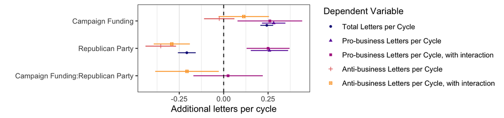

```r
## Full models + interactions
models <- tidy(mAll_Full) %>%
  mutate(model = "Total Letters per Cycle") %>%
  full_join(tidy(mPro_Full) %>%
              mutate(model = "Pro-business Letters per Cycle")) %>%
  full_join(tidy(mPro_Fullx) %>% mutate(model = "Pro-business Letters per Cycle, with interaction")) %>%
  full_join(tidy(mAnti_Full) %>%
              mutate(model = "Anti-business Letters per Cycle")) %>%
  full_join(tidy(mAnti_Fullx) %>% mutate(model = "Anti-business Letters per Cycle, with interaction")) %>%
  mutate(term = str_replace(term, "PAC_100k", "Campaign Funding"))# %>%  mutate(term = str_replace(term, "party\\(R\\)", "Republican"))

dplot(models) +
    labs(x = "Additional letters per cycle")
```

```r
write_lines(
  stargazer::stargazer(mAll_Full, mAll_Fullx,
                       mPro_Full,mPro_Fullx,
                       mAnti_Full, mAnti_Fullx,
                       covariate.labels = c("Campaign Contributions (100k)", "Republican", "Campaign Contributions × Republican"),
          dep.var.caption  = "Letters to FERC",
          dep.var.labels   = c("Total",
                               "Pro-business", "Anti-business", "Anti-business"), float=F),
  path = here("FERC/tables/mFull.tex"))


table <- stargazer(mAll_Full, mAll_Fullx,
                   mPro_Full,mPro_Fullx,
                   mAnti_Full, mAnti_Fullx,
                type = "html",
                notes = "FERC/tables/mFull.tex")

# NOTE THIS TABLE IS MISSING CONSTITUTENT
```

```r
htmltools::HTML(table)
```

|  | *Dependent variable:* |  |  |  |  |  |
| --- | --- | --- | --- | --- | --- | --- |
|  | total_letters |  | ProBusiness_Letters |  | AntiBusiness_Letters |  |
|  | (1) | (2) | (3) | (4) | (5) | (6) |
| PAC_100k | 0.243*** | 0.401*** | 0.282*** | 0.260*** | -0.025 | 0.113 |
|  | (0.018) | (0.034) | (0.034) | (0.093) | (0.044) | (0.072) |
| party_nameRepublican Party | -0.207*** | -0.134*** | 0.258*** | 0.250*** | -0.354*** | -0.292*** |
|  | (0.026) | (0.029) | (0.054) | (0.062) | (0.044) | (0.052) |
| PAC_100k:party_nameRepublican Party |  | -0.211*** |  | 0.025 |  | -0.207** |
|  |  | (0.041) |  | (0.100) |  | (0.091) |
| Constant | 0.104*** | 0.062*** | -1.618*** | -1.612*** | -0.791*** | -0.822*** |
|  | (0.018) | (0.020) | (0.041) | (0.047) | (0.029) | (0.032) |
| Observations | 5,997 | 5,997 | 5,997 | 5,997 | 5,997 | 5,997 |
| Log Likelihood | -12,573.380 | -12,560.840 | -4,200.879 | -4,200.848 | -6,150.805 | -6,148.318 |
| Akaike Inf. Crit. | 25,152.760 | 25,129.690 | 8,407.759 | 8,409.696 | 12,307.610 | 12,304.640 |
| *Note:* | *p<0.1; **p<0.05; ***p<0.01 |  |  |  |  |  |
|  | FERC/tables/mFull.tex |  |  |  |  |  |

# About FERC

FERC regulates electricity markets, oil and gas pipelines, and hydropower and gas export projects. Many of these decisions have major implications for business profits. For example, because many natural gas pipelines cross state lines, FERC largely controls pipeline market entry. Similarly, electricity grids are regional.

## Letters on behalf of projects in their districts

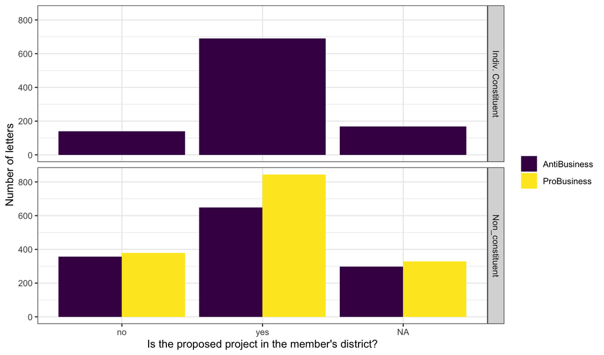

```r
d %>%
  mutate(Place_District = tolower(Place_District)) %>%
  # FIXME
  # dropping odd observations, will correct in DOE_FERC.R script
  filter(Place_District %in% c("yes", "no", NA)) %>%
  filter(letter_position %in% c("AntiBusiness", "ProBusiness")) %>%
  filter(Constituent != "Not coded") %>%
  count(Place_District, letter_position, Constituent) %>%
  ggplot() +
  aes(x = Place_District, y = n, fill = letter_position) +
  geom_col(position = "dodge") +
  facet_grid(Constituent ~ .)+
  labs(x = "Is the proposed project in the member's district?",
       y = "Number of letters",
       fill = "")
```

# TO DO

## DONE

- add clean text from scraper to google sheet
- fix clean function to pull and combine new data
- link industry codes to CRP PAC committee classification:
1. Identify relevant industry codes
2. Get cycle-specific PAC classification for those industry codes
3. Subset DIME to those PAC classifications
- Add 2015-2018 DIME
- Fix DIME ICPSRs

## FERC Paper 1 - Fix Goode, and other party switchers who are double counted as an R and I (dropped for now) - Identify companies that did not match a PAC and see if they match a parent company

## FERC Paper 2

- letters per company
- letters per company PAC (before and after merging in parent companies)
- add company names from company scraper to google sheet
- template to match company names to donation (lobbyview, DIME)
- template match company names to industry codes (center for responsive politics)
- Letters are on behalf of donors TODO
- Comparing FERC to other agencies TODO